# STAT 295 Homework 2

Başak Uğurlu Damla Başarmış Zeynep Fenercioğlu

## Question 1

```r
#Loading the data.
data <- read.csv("social_network_ad.csv")
```

```r
#Examining the data.
head(data)
```

```
##   X  User.ID Gender Age EstimatedSalary Purchased GiftTicket
## 1 1 15624510   Male  19           19000         0          0
## 2 2 15810944   Male  35           20000         0          1
## 3 3 15668575 Female  26           43000         0          0
## 4 4 15603246 Female  27           57000         0          0
## 5 5 15804002   Male  19           76000         0          0
## 6 6 15728773   Male  27           58000         0          0
```

```r
str(data)
```

```
## 'data.frame':    400 obs. of  7 variables:
##  $ X              : int  1 2 3 4 5 6 7 8 9 10 ...
##  $ User.ID        : int  15624510 15810944 15668575 15603246 15804002 15728773 15598044 15694829 15600575 15727311 ...
##  $ Gender         : chr  "Male" "Male" "Female" "Female" ...
##  $ Age            : int  19 35 26 27 19 27 27 32 25 35 ...
##  $ EstimatedSalary: int  19000 20000 43000 57000 76000 58000 84000 150000 33000 65000 ...
##  $ Purchased      : int  0 0 0 0 0 0 0 1 0 0 ...
##  $ GiftTicket     : int  0 1 0 0 0 0 0 1 0 1 ...
```

```r
summary(data)
```

```
##        X            User.ID            Gender               Age
##  Min.   :  1.0   Min.   :15566689   Length:400         Min.   :18.00
##  1st Qu.:100.8   1st Qu.:15626764   Class :character   1st Qu.:29.75
##  Median :200.5   Median :15694342   Mode  :character   Median :37.00
##  Mean   :200.5   Mean   :15691540                      Mean   :37.66
##  3rd Qu.:300.2   3rd Qu.:15750363                      3rd Qu.:46.00
##  Max.   :400.0   Max.   :15815236                      Max.   :60.00
##  EstimatedSalary    Purchased        GiftTicket
##  Min.   : 15000   Min.   :0.0000   Min.   :0.0000
##  1st Qu.: 43000   1st Qu.:0.0000   1st Qu.:0.0000
##  Median : 70000   Median :0.0000   Median :1.0000
##  Mean   : 69743   Mean   :0.3575   Mean   :0.7225
##  3rd Qu.: 88000   3rd Qu.:1.0000   3rd Qu.:1.0000
##  Max.   :150000   Max.   :1.0000   Max.   :1.0000
```

User.ID: This is a unique identifier for each user, which doesn’t have a meaningful summary statistic.

Gender: The dataset includes both male and female customers.

Age: The age variable ranges from young adults to older individuals, with a minimum age of 18 and a maximum age of 60.

EstimatedSalary: This variable shows the estimated salary of individuals, ranging from low to high-income levels, with salaries between 15,000 and 150,000.

### i.

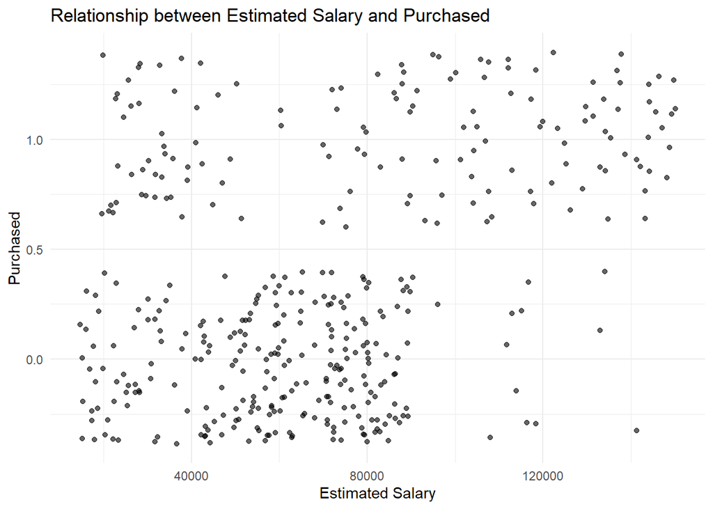

```r
# Loading necessary libraries
library(ggplot2)

# Creating the plot
ggplot(data, aes(x = EstimatedSalary, y = Purchased)) +
  geom_jitter(alpha=0.6) +
  labs(title = "Relationship between Estimated Salary and Purchased",
       x = "Estimated Salary",
       y = "Purchased") +
  theme_minimal()
```

The scatter plot shows the relationship between EstimatedSalary (x-axis) and Purchased (y-axis). Each point represents an individual in the dataset. The Purchased variable is binary, taking the value of 0 or 1, indicating whether the individual purchased a product. From the plot, we can analyze whether there is a clear pattern or trend between the estimated salary of individuals and their likelihood of purchasing a product. For instance, we might look for clusters or trends that indicate higher or lower probabilities of purchasing based on salary. Detailed Analysis Clustering: Observe if there are any clusters of individuals who purchased the product at certain salary ranges. Trend: Determine if there is a positive or negative correlation between salary and purchasing behavior. We see that there is more salary variation at users who purchase, for users who don’t purchase there is a cluster on the left part which indicates lower salaries.

### ii.

```r
# Fitting the logistic regression model
model <- glm(Purchased ~ EstimatedSalary, data = data, family = binomial)

# Summary of the model
summary(model)
```

```
##
## Call:
## glm(formula = Purchased ~ EstimatedSalary, family = binomial,
##     data = data)
##
## Coefficients:
##                   Estimate Std. Error z value Pr(>|z|)
## (Intercept)     -2.323e+00  2.855e-01  -8.134 4.14e-16 ***
## EstimatedSalary  2.388e-05  3.516e-06   6.790 1.12e-11 ***
## ---
## Signif. codes:  0 '***' 0.001 '**' 0.01 '*' 0.05 '.' 0.1 ' ' 1
##
## (Dispersion parameter for binomial family taken to be 1)
##
##     Null deviance: 521.57  on 399  degrees of freedom
## Residual deviance: 467.73  on 398  degrees of freedom
## AIC: 471.73
##
## Number of Fisher Scoring iterations: 4
```

```r
# Extracting coefficients
coefficients <- summary(model)$coefficients
coefficients
```

```
##                      Estimate   Std. Error   z value     Pr(>|z|)
## (Intercept)     -2.322700e+00 2.855402e-01 -8.134406 4.139621e-16
## EstimatedSalary  2.387492e-05 3.516280e-06  6.789822 1.122722e-11
```

```r
#Odds of purchasing a particular product. The coefficient b_1 represents the change in the log-odds of purchasing a product for a one-unit increase in EstimatedSalary.

# Exponentiating the coefficient for EstimatedSalary
exp_beta1 <- exp(coefficients["EstimatedSalary", "Estimate"])
exp_beta1
```

```
## [1] 1.000024
```

Coefficient b_1 is positive, it means that as EstimatedSalary increases, the odds of purchasing a product increase.

### iii.

```r
# Coefficients from the logistic regression model
beta_0 <- coefficients["(Intercept)", "Estimate"]
beta_1 <- coefficients["EstimatedSalary", "Estimate"]

# Estimated salary of $22,000
salary <- 22000

# Calculating the log-odds
log_odds <- beta_0 + beta_1 * salary

# Converting log-odds to probability
probability <- exp(log_odds) / (1 + exp(log_odds))
probability
```

```
## [1] 0.1421615
```

This means that an individual with an estimated salary of $22,000 has a predicted probability of 14% of purchasing the product. This finding indicates that while the probability of purchasing increases with estimated salary, it is still moderate for a salary of $22,000, reflecting the logistic nature of the model where probabilities range between 0 and 1 but do not increase linearly.

### iv.

```r
# Converting Gender to binary variables
data$GenderBinary <- ifelse(data$Gender == "Male", 1, 0)

# Checking the transformation
head(data)
```

```
##   X  User.ID Gender Age EstimatedSalary Purchased GiftTicket GenderBinary
## 1 1 15624510   Male  19           19000         0          0            1
## 2 2 15810944   Male  35           20000         0          1            1
## 3 3 15668575 Female  26           43000         0          0            0
## 4 4 15603246 Female  27           57000         0          0            0
## 5 5 15804002   Male  19           76000         0          0            1
## 6 6 15728773   Male  27           58000         0          0            1
```

```r
# Fitting the logistic regression model with GenderBinary
model_gender <- glm(Purchased ~ GenderBinary, data = data, family = binomial)

# Summary of the model
summary(model_gender)
```

```
##
## Call:
## glm(formula = Purchased ~ GenderBinary, family = binomial, data = data)
##
## Coefficients:
##              Estimate Std. Error z value Pr(>|z|)
## (Intercept)   -0.5004     0.1444  -3.464 0.000531 ***
## GenderBinary  -0.1775     0.2091  -0.849 0.395858
## ---
## Signif. codes:  0 '***' 0.001 '**' 0.01 '*' 0.05 '.' 0.1 ' ' 1
##
## (Dispersion parameter for binomial family taken to be 1)
##
##     Null deviance: 521.57  on 399  degrees of freedom
## Residual deviance: 520.85  on 398  degrees of freedom
## AIC: 524.85
##
## Number of Fisher Scoring iterations: 4
```

```r
# Extracting coefficients for the gender model
coefficients_gender <- summary(model_gender)$coefficients
coefficients_gender
```

```
##                Estimate Std. Error    z value     Pr(>|z|)
## (Intercept)  -0.5003817  0.1444335 -3.4644439 0.0005313289
## GenderBinary -0.1774980  0.2090570 -0.8490412 0.3958583422
```

```r
# Exponentiating the coefficient for GenderBinary
exp_beta1_gender <- exp(coefficients_gender["GenderBinary", "Estimate"])
exp_beta1_gender
```

```
## [1] 0.8373626
```

### v.

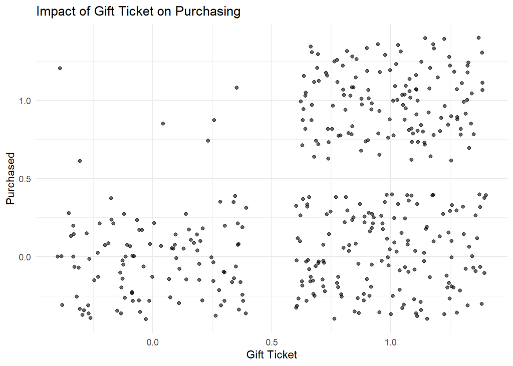

```r
# Creating the plot
ggplot(data, aes(x = GiftTicket, y = Purchased)) +
  geom_jitter(alpha=0.6) +
  labs(title = "Impact of Gift Ticket on Purchasing",
       x = "Gift Ticket",
       y = "Purchased") +
  theme_minimal()
```

The plot shows the relationship between having a gift ticket (GiftTicket) and purchasing a product (Purchased). Each point represents purchases (1) and non-purchases (0) for individuals with and without a gift ticket. From the plot, we can observe the amount of purchases among individuals who received a gift ticket is significantly more compared to those who did not.

```r
# Fitting the logistic regression model with GiftTicket
model_gift <- glm(Purchased ~ GiftTicket, data = data, family = binomial)

# Summary of the model
summary(model_gift)
```

```
##
## Call:
## glm(formula = Purchased ~ GiftTicket, family = binomial, data = data)
##
## Coefficients:
##             Estimate Std. Error z value Pr(>|z|)
## (Intercept)  -2.8622     0.4197  -6.819 9.17e-12 ***
## GiftTicket    2.7583     0.4360   6.327 2.50e-10 ***
## ---
## Signif. codes:  0 '***' 0.001 '**' 0.01 '*' 0.05 '.' 0.1 ' ' 1
##
## (Dispersion parameter for binomial family taken to be 1)
##
##     Null deviance: 521.57  on 399  degrees of freedom
## Residual deviance: 446.54  on 398  degrees of freedom
## AIC: 450.54
##
## Number of Fisher Scoring iterations: 5
```

```r
# Extracting coefficients for the gift model
coefficients_gift <- summary(model_gift)$coefficients
coefficients_gift
```

```
##              Estimate Std. Error   z value     Pr(>|z|)
## (Intercept) -2.862201  0.4197394 -6.818996 9.167922e-12
## GiftTicket   2.758301  0.4359580  6.326989 2.499912e-10
```

The coefficient b_1 is positive, it indicates that individuals with a gift ticket have higher odds of purchasing the product compared to those without.

```r
# Exponentiating the coefficient for GiftTicket
exp_beta1_gift <- exp(coefficients_gift["GiftTicket", "Estimate"])
exp_beta1_gift
```

```
## [1] 15.77303
```

This means that the odds of purchasing a product for individuals with a gift ticket are approximately 15.77 times higher compared.

### vi.

```r
# Predicting probabilities using the logistic regression model
predicted_probs <- predict(model_gift, type = "response")

# Adding predicted probabilities to the dataset
data$PredictedProbability <- predicted_probs

# Grouping the data by GiftTicket and calculating mean predicted probability
predicted_probs_by_gift <- aggregate(PredictedProbability ~ GiftTicket, data = data, FUN = mean)
predicted_probs_by_gift
```

```
##   GiftTicket PredictedProbability
## 1          0           0.05405405
## 2          1           0.47404844
```

## Question 2

```r
#Loading the data
AB_NYC_2019 <- read.csv("AB_NYC_2019.csv")
AB_NYC_2019<-as.data.frame(AB_NYC_2019)
```

```r
# Define UI for application
ui <- fluidPage(

  # Application title
  titlePanel("Choose Your Airbnb in New York"),

  # Sidebar with a slider input for user choices
  sidebarLayout(
    sidebarPanel(
      h2("Which neighbourhood is best for your Airbnb?"),
      br(),
      sliderInput(inputId = "price", label = "Price", min = 0, max = 2000, value = 500),
      sliderInput(inputId = "minimum_nights", label = "Minimum Nights", min = 1, max = 365, value = 50),
      sliderInput(inputId = "number_of_reviews", label = "Number of Reviews", min = 0, max = 500, value = 300),
      sliderInput(inputId = "reviews_per_month", label = "Reviews Per Month", min = 0, max = 50, value = 30),
      sliderInput(inputId = "calculated_host_listings_count", label = "Calculated Host Listing Count", min = 1, max = 30, value = 20),
      sliderInput(inputId = "availability_365", label = "Availability (days per year)", min = 0, max = 365, value = 200)
    ),
    #Texts that will be seen in the webpage
    mainPanel(
      uiOutput("img"),
      br(),
      p(h3("Your Choices:")),
      textOutput("Price_out"),
      textOutput("Minimum_nights_out"),
      textOutput("number_of_reviews_out"),
      textOutput("reviews_per_month_out"),
      textOutput("calculated_host_listings_count_out"),
      textOutput("availability_365_out"),
      br(),
      p(h2("Best Neighbourhood For You:")),
      br(),
      textOutput("Neighbourhood"),
      br(),
      br(),
      p(h4(strong("About the app:"))),
      p(h5("In the shiny app, the formula considers several factors from the dataset: price, minimum_nights,
           number_of_reviews, reviews_per_month, calculated_host_listings_count, availability.
           Users can choose these factors according to their preferences. The app displays the neighbourhood that fits best to users choices."))
    )
  )
)
server <- function(input, output) {
  #The part that will show user input in an organized way
  output$img <- renderUI({
    tags$img(src = "https://storage.googleapis.com/kaggle-datasets-images/268833/559075/cf825b5af1f904cd1ea6404039abc88e/dataset-cover.jpg?t=2019-07-18-19-19-53", width = 900, height = 350)
  })

  output$Price_out <- renderText({
    input$Calculate
    paste("Price:", input$price)
  })

  output$Minimum_nights_out <- renderText({
    input$Calculate
    paste("Minimum Nights Out:", input$minimum_nights)
  })

  output$number_of_reviews_out <- renderText({
    input$Calculate
    paste("Number of Reviews:", input$number_of_reviews)
  })

  output$reviews_per_month_out <- renderText({
    input$Calculate
    paste("Reviews per Month:", input$reviews_per_month)
  })

  output$calculated_host_listings_count_out <- renderText({
    input$Calculate
    paste("Calculated Host Listings:", input$calculated_host_listings_count)
  })

  output$availability_365_out <- renderText({
    input$Calculate
    paste("Availability:", input$availability_365)
  })

  #Formula matches user choices with neighborhoods by calculating neighborhoods first and third quartiles for each variable, and compares whether user input falls between them to make a good estimation without outliers, around median. It shows the neighborhood with the most matches.
  result <- reactive({
    AB_NYC_2019 <- read.csv("AB_NYC_2019.csv")

    quartiles <- AB_NYC_2019 %>%
      group_by(neighbourhood_group) %>%
      summarize(
        Price_Q1 = quantile(price, 0.25, na.rm = TRUE),
        Price_Q3 = quantile(price, 0.75, na.rm = TRUE),
        Minimum_Nights_Q1 = quantile(minimum_nights, 0.25, na.rm = TRUE),
        Minimum_Nights_Q3 = quantile(minimum_nights, 0.75, na.rm = TRUE),
        Number_of_Reviews_Q1 = quantile(number_of_reviews, 0.25, na.rm = TRUE),
        Number_of_Reviews_Q3 = quantile(number_of_reviews, 0.75, na.rm = TRUE),
        Reviews_per_Month_Q1 = quantile(reviews_per_month, 0.25, na.rm = TRUE),
        Reviews_per_Month_Q3 = quantile(reviews_per_month, 0.75, na.rm = TRUE),
        Calculated_Host_Listings_Count_Q1 = quantile(calculated_host_listings_count, 0.25, na.rm = TRUE),
        Calculated_Host_Listings_Count_Q3 = quantile(calculated_host_listings_count, 0.75, na.rm = TRUE),
        Availability_Q1 = quantile(availability_365, 0.25, na.rm = TRUE),
        Availability_Q3 = quantile(availability_365, 0.75, na.rm = TRUE)
      )

    matches <- quartiles %>%
      mutate(
        Price_Match = input$price >= Price_Q1 & input$price <= Price_Q3,
        Minimum_Nights_Match = input$minimum_nights >= Minimum_Nights_Q1 & input$minimum_nights <= Minimum_Nights_Q3,
        Number_of_Reviews_Match = input$number_of_reviews >= Number_of_Reviews_Q1 & input$number_of_reviews <= Number_of_Reviews_Q3,
        Reviews_per_Month_Match = input$reviews_per_month >= Reviews_per_Month_Q1 & input$reviews_per_month <= Reviews_per_Month_Q3,
        Calculated_Host_Listings_Count_Match = input$calculated_host_listings_count >= Calculated_Host_Listings_Count_Q1 & input$calculated_host_listings_count <= Calculated_Host_Listings_Count_Q3,
        Availability_Match = input$availability_365 >= Availability_Q1 & input$availability_365 <= Availability_Q3,
        Match_Score = Price_Match + Minimum_Nights_Match + Number_of_Reviews_Match + Reviews_per_Month_Match + Calculated_Host_Listings_Count_Match + Availability_Match
      ) %>%
      filter(Match_Score > 0) %>%
      arrange(desc(Match_Score))

    if (nrow(matches) == 0) {
      return("No neighbourhood matches the given inputs within their 25th and 75th percentiles.")
    } else {
      return(paste("The best matching neighbourhood based on your inputs:",
                   matches$neighbourhood_group[1])) # It shows only the most matched neighborhood.
    }
  })

  output$Neighbourhood <- renderText({
    result()
  })
}

shinyApp(ui = ui, server = server)
```

Shiny applications not supported in static R Markdown documents